# Econometria espacial com R - Matrizes

Unicamp, julho de 2021

Raphael Saldanha, Eduardo Almeida

# Análise Exploratória de Dados Espaciais

## Leitura do shapefile

Para a leitura de arquivos **shapefile** no R, precisamos usar alguns pacotes. Após a instalação dos pacotes, use os seguintes comandos.

```r
# Pacotes
library(rgdal)
# Abra o arquivo 'gm10.shp'
fp_mg.shp <- readOGR("data", "FP_MG", encoding = "ISO-8859-1")
```

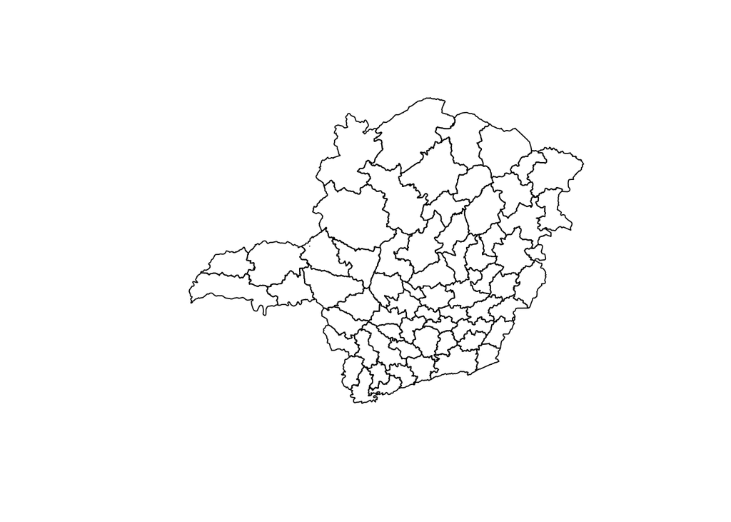

```r
# Plotar o mapa
plot(fp_mg.shp)
```

## Atributos do shapefile

Podemos ver a tabela de atributos do shapefile com desta forma.

```r
head(fp_mg.shp@data)
```

```
##   CODMIC      NOMMIC      Q     AC     AP    K   R  RP RNP DRNP   F    AREA
## 0     41     Aimorés 134310  60132  60132 1833 363 155 208   25  84  8354.1
## 1     49     Alfenas 564476 113253 113253 7203 312 273  39    8   1  4998.9
## 2     14    Almenara  84631  20737  20737  783 383 150 233   15   1 15504.5
## 3     55 Andrelândia  59164  27764  27764 1154 264 200  64   13 227  5047.3
## 4     12     Araçuaí 159897  36779  36779  552 315 162 153   15   1 10299.4
## 5     23       Araxá 495102 160580 160643 7582 645 564  81    6 327 14145.6
##   ESCTOT POPTOT    LP   ACP    KP   ETOTP   DRNPP       FP     RNPP      RPP
## 0    347 152658 0.111 0.394 0.012 0.00227 0.00016 0.000550 0.001363 0.001015
## 1    229 179366 0.111 0.631 0.040 0.00128 0.00004 0.000006 0.000217 0.001522
## 2    384 213342 0.047 0.097 0.004 0.00180 0.00007 0.000005 0.001092 0.000703
## 3    191  70783 0.037 0.392 0.016 0.00270 0.00018 0.003207 0.000904 0.002826
## 4    327 143468 0.143 0.256 0.004 0.00228 0.00010 0.000007 0.001066 0.001129
## 5    182 158275 0.043 1.015 0.048 0.00115 0.00004 0.002066 0.000512 0.003563
##        R_P       QP   X_COORD   Y_COORD CMICRO     VP      VPP    LA   LM     L
## 0 0.002378 0.879810 -41.38876 -19.53116  31041  78349 0.513232 42737 3997 46734
## 1 0.001739 3.147062 -46.01852 -21.37551  31049 216064 1.204598 33737 1118 34855
## 2 0.001795 0.396692 -40.65978 -16.35385  31014  40164 0.188261 30920 4259 35179
## 3 0.003730 0.835850 -44.44562 -21.95045  31055  42360 0.598449 15135  908 16043
## 4 0.002196 1.114513 -41.87023 -17.00645  31012  28864 0.201188 45015 7069 52084
## 5 0.004075 3.128112 -46.95948 -19.59779  31023 197010 1.244732 23442 1488 24930
##   CO_RUR  NU_RUR   CO_TOT      EER      K_L VEG TEMP PREC     KL
## 0   4937 1314045  4402218 0.003757 0.039222   1    4    1 0.0392
## 1   6736 2957879 12228817 0.002277 0.206656   2    2    3 0.2067
## 2   1431  282421  3363297 0.005067 0.022258   2    5    1 0.0223
## 3   1717  498819  2819950 0.003442 0.071932   2    1    4 0.0719
## 4   1431  365829  2404595 0.003912 0.010598   3    4    1 0.0106
## 5   4357 1476959 14220985 0.002950 0.304132   1    2    4 0.3041
```

## Mapa

Podemos produzir um mapa colorido com os seguintes comandos.

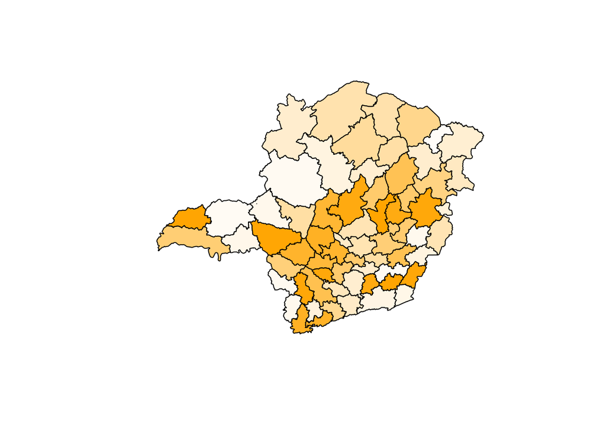

```r
p <- colorRampPalette(c("white", "orange"))(128)
palette(p)
plot(fp_mg.shp, col = fp_mg.shp@data$Q)
```

### Sua vez

Faça um mapa com a variável AC com a cor vermelha.

## Matriz de vizinhos espaciais

Para a criação de matrizes de vizinhos espaciais, iremos utilizar o pacote `spdep`.

```r
# Pacote
library(spdep)
```

### Matriz queen e rook

```r
# Matriz queen
w1 <- nb2listw(poly2nb(fp_mg.shp, queen = TRUE))
summary(w1)
```

```
## Characteristics of weights list object:
## Neighbour list object:
## Number of regions: 66
## Number of nonzero links: 336
## Percentage nonzero weights: 7.713499
## Average number of links: 5.090909
## Link number distribution:
##
##  2  3  4  5  6  7  8  9
##  2  9 12 16 16  8  2  1
## 2 least connected regions:
## 28 37 with 2 links
## 1 most connected region:
## 64 with 9 links
##
## Weights style: W
## Weights constants summary:
##    n   nn S0       S1       S2
## W 66 4356 66 27.58858 269.8006
```

```r
# Matriz queen 2ª ordem
w1.2 <- nb2listw(nblag_cumul(nblag(poly2nb(fp_mg.shp, queen = TRUE), maxlag = 2)))

# Matrix queen padronizada na linha
w1.w <- nb2listw(poly2nb(fp_mg.shp, queen=TRUE), style="W")
summary(w1.w)
```

```
## Characteristics of weights list object:
## Neighbour list object:
## Number of regions: 66
## Number of nonzero links: 336
## Percentage nonzero weights: 7.713499
## Average number of links: 5.090909
## Link number distribution:
##
##  2  3  4  5  6  7  8  9
##  2  9 12 16 16  8  2  1
## 2 least connected regions:
## 28 37 with 2 links
## 1 most connected region:
## 64 with 9 links
##
## Weights style: W
## Weights constants summary:
##    n   nn S0       S1       S2
## W 66 4356 66 27.58858 269.8006
```

```r
# Matriz rook
w2 <- nb2listw(poly2nb(fp_mg.shp, queen = FALSE))
summary(w2)
```

```
## Characteristics of weights list object:
## Neighbour list object:
## Number of regions: 66
## Number of nonzero links: 332
## Percentage nonzero weights: 7.621671
## Average number of links: 5.030303
## Link number distribution:
##
##  2  3  4  5  6  7  8
##  2  9 12 18 15  7  3
## 2 least connected regions:
## 28 37 with 2 links
## 3 most connected regions:
## 11 25 64 with 8 links
##
## Weights style: W
## Weights constants summary:
##    n   nn S0       S1       S2
## W 66 4356 66 27.82221 269.6778
```

```r
# Matriz rook padronizada globalmente
w2.c <- nb2listw(poly2nb(fp_mg.shp, queen = FALSE), style = "C")
summary(w2.c)
```

```
## Characteristics of weights list object:
## Neighbour list object:
## Number of regions: 66
## Number of nonzero links: 332
## Percentage nonzero weights: 7.621671
## Average number of links: 5.030303
## Link number distribution:
##
##  2  3  4  5  6  7  8
##  2  9 12 18 15  7  3
## 2 least connected regions:
## 28 37 with 2 links
## 3 most connected regions:
## 11 25 64 with 8 links
##
## Weights style: C
## Weights constants summary:
##    n   nn S0       S1      S2
## C 66 4356 66 26.24096 285.489
```

### Distância inversa

```r
coords <- coordinates(fp_mg.shp)
nb <- dnearneigh(coords, 0, 1000)
dlist <- nbdists(nb, coords)
dlist <- lapply(dlist, function(x) 1/x)
w3 <- nb2listw(nb, glist=dlist)
summary(w3)
```

```
## Characteristics of weights list object:
## Neighbour list object:
## Number of regions: 66
## Number of nonzero links: 4290
## Percentage nonzero weights: 98.48485
## Average number of links: 65
## Link number distribution:
##
## 65
## 66
## 66 least connected regions:
## 1 2 3 4 5 6 7 8 9 10 11 12 13 14 15 16 17 18 19 20 21 22 23 24 25 26 27 28 29 30 31 32 33 34 35 36 37 38 39 40 41 42 43 44 45 46 47 48 49 50 51 52 53 54 55 56 57 58 59 60 61 62 63 64 65 66 with 65 links
## 66 most connected regions:
## 1 2 3 4 5 6 7 8 9 10 11 12 13 14 15 16 17 18 19 20 21 22 23 24 25 26 27 28 29 30 31 32 33 34 35 36 37 38 39 40 41 42 43 44 45 46 47 48 49 50 51 52 53 54 55 56 57 58 59 60 61 62 63 64 65 66 with 65 links
##
## Weights style: W
## Weights constants summary:
##    n   nn S0       S1       S2
## W 66 4356 66 3.016494 266.1162
```

```r
# Distância inversa padronizada pelo número de vizinhos
w3.u <- nb2listw(nb, glist=dlist, style="U")
summary(w3.u)
```

```
## Characteristics of weights list object:
## Neighbour list object:
## Number of regions: 66
## Number of nonzero links: 4290
## Percentage nonzero weights: 98.48485
## Average number of links: 65
## Link number distribution:
##
## 65
## 66
## 66 least connected regions:
## 1 2 3 4 5 6 7 8 9 10 11 12 13 14 15 16 17 18 19 20 21 22 23 24 25 26 27 28 29 30 31 32 33 34 35 36 37 38 39 40 41 42 43 44 45 46 47 48 49 50 51 52 53 54 55 56 57 58 59 60 61 62 63 64 65 66 with 65 links
## 66 most connected regions:
## 1 2 3 4 5 6 7 8 9 10 11 12 13 14 15 16 17 18 19 20 21 22 23 24 25 26 27 28 29 30 31 32 33 34 35 36 37 38 39 40 41 42 43 44 45 46 47 48 49 50 51 52 53 54 55 56 57 58 59 60 61 62 63 64 65 66 with 65 links
##
## Weights style: U
## Weights constants summary:
##    n   nn S0           S1         S2
## U 66 4356  1 0.0007459454 0.06384681
```

Para ver mais opções, veja a ajuda deste comando: `?nb2listw`

### Matriz de k-vizinhos espaciais

A escolha do número ideal de $k$ vizinhos será realizada testando-se vários $k$ e utilizando-se o que retornou o maior valor para a estatística $I$ de Moran significativo.

```r
# Número de permutações
per <- 999

# Número máximo de k vizinhos testados
kv <- 20

# Nome dos registros
IDs <- row.names(fp_mg.shp@data)

# Criação da tabela que irá receber a estatística I de Moran e significância para cada k testado
res.pesos <- data.frame(k=numeric(),i=numeric(),valorp=numeric())

# Início do loop
for(k in 1:kv)
{
  # Armazenando número k atual
  res.pesos[k,1] <- k
  # Calculando o I e significância para o k atual
  moran.k <- moran.mc(fp_mg.shp@data$Q,
                      listw=nb2listw(knn2nb(
                      knearneigh(coords, k=k),
                      row.names=IDs),style="B"),
                      nsim=per)
  # Armazenando o valor I para o k atual
  res.pesos[k,2] <- moran.k$statistic
  # Armazenando o p-value para o k atual
  res.pesos[k,3] <- moran.k$p.value
}

# Ver a tabela de k vizinhos, I de Moran e significância
res.pesos
```

```
##     k         i valorp
## 1   1 0.5228074  0.004
## 2   2 0.3875458  0.004
## 3   3 0.4531317  0.001
## 4   4 0.4199339  0.001
## 5   5 0.3944831  0.001
## 6   6 0.3595862  0.001
## 7   7 0.3461349  0.001
## 8   8 0.3286129  0.001
## 9   9 0.3064023  0.001
## 10 10 0.3157462  0.001
## 11 11 0.3028398  0.001
## 12 12 0.2942354  0.001
## 13 13 0.2791438  0.001
## 14 14 0.2620697  0.001
## 15 15 0.2541920  0.001
## 16 16 0.2429784  0.001
## 17 17 0.2320723  0.001
## 18 18 0.2213339  0.001
## 19 19 0.2117356  0.001
## 20 20 0.2017898  0.001
```

```r
# Sendo todos significativos, iremos usar o k que retornou o maior valor I
maxi <- which.max(res.pesos[,2])

# Criação da matriz usando o k escolhido
w5 <- nb2listw(knn2nb(knearneigh(coords, k=maxi),row.names=IDs),style="B")
summary(w5)
```

```
## Characteristics of weights list object:
## Neighbour list object:
## Number of regions: 66
## Number of nonzero links: 66
## Percentage nonzero weights: 1.515152
## Average number of links: 1
## Non-symmetric neighbours list
## Link number distribution:
##
##  1
## 66
## 66 least connected regions:
## 0 1 2 3 4 5 6 7 8 9 10 11 12 13 14 15 16 17 18 19 20 21 22 23 24 25 26 27 28 29 30 31 32 33 34 35 36 37 38 39 40 41 42 43 44 45 46 47 48 49 50 51 52 53 54 55 56 57 58 59 60 61 62 63 64 65 with 1 link
## 66 most connected regions:
## 0 1 2 3 4 5 6 7 8 9 10 11 12 13 14 15 16 17 18 19 20 21 22 23 24 25 26 27 28 29 30 31 32 33 34 35 36 37 38 39 40 41 42 43 44 45 46 47 48 49 50 51 52 53 54 55 56 57 58 59 60 61 62 63 64 65 with 1 link
##
## Weights style: B
## Weights constants summary:
##    n   nn S0 S1  S2
## B 66 4356 66 98 308
```

## Autocorrelação espacial global

### I de Moran

```r
moran.test(fp_mg.shp@data$Q, listw = w5)
```

```
##
##  Moran I test under randomisation
##
## data:  fp_mg.shp@data$Q
## weights: w5
##
## Moran I statistic standard deviate = 3.8645, p-value = 5.566e-05
## alternative hypothesis: greater
## sample estimates:
## Moran I statistic       Expectation          Variance
##        0.52280745       -0.01538462        0.01939499
```

```r
moran.mc(fp_mg.shp@data$Q, listw = w5, nsim = 999)
```

```
##
##  Monte-Carlo simulation of Moran I
##
## data:  fp_mg.shp@data$Q
## weights: w5
## number of simulations + 1: 1000
##
## statistic = 0.52281, observed rank = 997, p-value = 0.003
## alternative hypothesis: greater
```

### C de Geary

```r
geary.test(fp_mg.shp@data$Q, listw = w5)
```

```
##
##  Geary C test under randomisation
##
## data:  fp_mg.shp@data$Q
## weights: w5
##
## Geary C statistic standard deviate = 2.6176, p-value = 0.004428
## alternative hypothesis: Expectation greater than statistic
## sample estimates:
## Geary C statistic       Expectation          Variance
##        0.46130049        1.00000000        0.04235442
```

```r
geary.mc(fp_mg.shp@data$Q, listw = w5, nsim = 999)
```

```
##
##  Monte-Carlo simulation of Geary C
##
## data:  fp_mg.shp@data$Q
## weights: w5
## number of simulations + 1: 1000
##
## statistic = 0.4613, observed rank = 2, p-value = 0.002
## alternative hypothesis: greater
```

### G de Getis-Ord

```r
globalG.test(as.vector(scale(fp_mg.shp@data$Q, center = FALSE)), listw = w5, B1correct = TRUE)
```

```
##
##  Getis-Ord global G statistic
##
## data:  as.vector(scale(fp_mg.shp@data$Q, center = FALSE))
## weights: w5
##
## standard deviate = 3.2113, p-value = 0.0006607
## alternative hypothesis: greater
## sample estimates:
## Global G statistic        Expectation           Variance
##       3.071155e-02       1.538462e-02       2.277991e-05
```

## Autocorrelação espacial local

### G de Gettis-Ords

```r
lg1 <- localG(fp_mg.shp@data$Q, listw = w5)
summary(lg1)
```

```
##     Min.  1st Qu.   Median     Mean  3rd Qu.     Max.
## -0.69900 -0.53552 -0.44190 -0.04454 -0.06779  4.21616
```

### I de Moran

```r
# Cálculo
lm1 <- localmoran(fp_mg.shp@data$Q, listw = w5)
summary(lm1)
```

```
##        Ii                E.Ii              Var.Ii            Z.Ii
##  Min.   :-0.83956   Min.   :-0.01538   Min.   :0.8627   Min.   :-0.88734
##  1st Qu.: 0.07066   1st Qu.:-0.01538   1st Qu.:0.8627   1st Qu.: 0.09264
##  Median : 0.20075   Median :-0.01538   Median :0.8627   Median : 0.23270
##  Mean   : 0.52281   Mean   :-0.01538   Mean   :0.8627   Mean   : 0.57944
##  3rd Qu.: 0.27959   3rd Qu.:-0.01538   3rd Qu.:0.8627   3rd Qu.: 0.31759
##  Max.   :11.31579   Max.   :-0.01538   Max.   :0.8627   Max.   :12.19963
##    Pr(z > 0)
##  Min.   :0.0000
##  1st Qu.:0.3754
##  Median :0.4080
##  Mean   :0.4216
##  3rd Qu.:0.4631
##  Max.   :0.8126
```

```r
# Quantos são significativos?
lm1 <- as.data.frame(lm1)
table(lm1$`Pr(z > 0)`<0.05)
```

```
##
## FALSE  TRUE
##    62     4
```

## Diagrama de dispersão de Moran

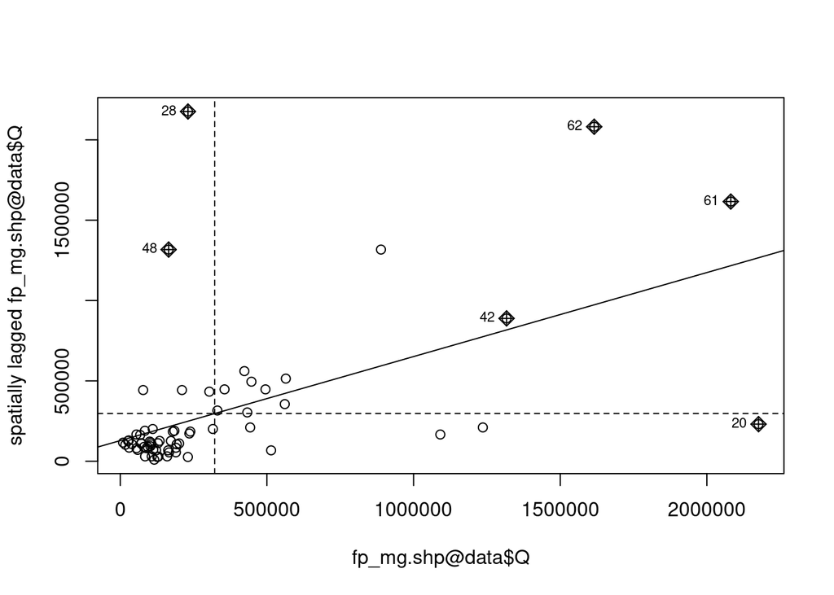

```r
moran.plot(fp_mg.shp@data$Q, listw = w5)
```

### Sua vez

Calcule o I de Moran local usando a matriz de vizinhança `w1` para a variável `AC`e verifique quantas regiões são significativas. Depois, faça o diagrama de dispersão.

## LISA map

O R não tem uma função pronta para criar um mapa LISA, então nós criamos abaixo nossa própria função: `lisaplot`. Depois de declarada, uma função pode ser usada repetidamente variando seus argumentos.

Rode o código abaixo.

```r
lisaplot <- function(shapefile, values, listw, pval = 0.05){
  require(spdep)

  svalues <- as.vector(scale(values, scale = FALSE))
  lag_svalues <- spdep::lag.listw(listw, svalues)
  locm <- spdep::localmoran(values, listw)
  sig <- rep(0, length(values))

  sig[(svalues >= 0 & lag_svalues >= 0) & (locm[,5] <= pval)] <- 1
  sig[(svalues <= 0 & lag_svalues <= 0) & (locm[,5] <= pval)] <- 2
  sig[(svalues >= 0 & lag_svalues <= 0) & (locm[,5] <= pval)] <- 3
  sig[(svalues <= 0 & lag_svalues >= 0) & (locm[,5] <= pval)] <- 4
  sig[locm[,5] > pval] <- 5

  breaks <- seq(1, 5, 1)
  labels <- c("Alto-Alto", "Baixo-Baixo", "Alto-Baixo", "Baixo-Alto", "N. Sig.")
  np <- findInterval(sig, breaks)
  colors <- c("red", "blue", "lightpink", "skyblue2", "white")
  plot(shapefile, col = colors[np])
  mtext("LISA", cex = 1.5, side = 3, line = 1)
  legend("topleft", legend = labels, fill = colors, bty = "n")
}
```

E o LISA para a variável `TEMP`.

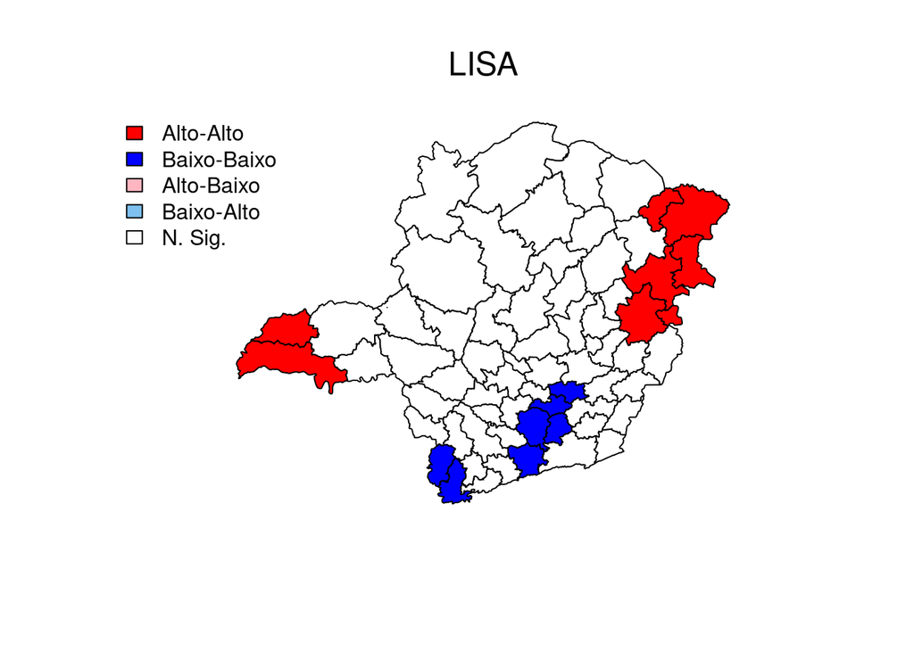

```r
lisaplot(fp_mg.shp, fp_mg.shp@data$TEMP, w5)
```

### Sua vez

Faça o LISA para a variável `AP` com a matriz `w1`.